# Solve MountainCar using Q-Learning with function approximation

Markus Dumke

2017-04-11

## MountainCar

MountainCar is a classical reinforcement learning problem. The goal is to drive a car up a hill. The car cannot drive the hill up in a single pass, so it first needs to go backwards, build up momentum and then go forwards into the goal. The state space is characterized by velocity and position, each continuous within certain bounds. Actions include throttle backward, forward or not at all (- 1, 0, + 1), so the action space is discrete.

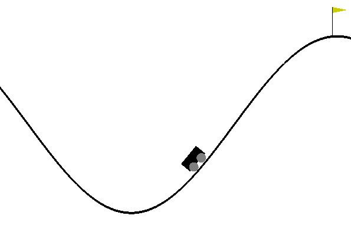

Mountain Car environment

In the following we will try to solve a simplified version of the problem, which allows 10000 steps per episode.

## Q-Learning

Q-Learning is an off-policy control algorithm using temporal-difference learning. Given a state and action pair the next state $S'$ and Reward $R$ are sampled from the environment. Then we take the max of the Q values of all possible successor actions. The action value of $S$ and $A$ is then updated towards the observed reward plus a discounted (discount factor $\gamma$) Q value of the next state $S'$ and best action $a$.

The update equation is:

$Q(S, A) \leftarrow Q(S, A) + \alpha[R + \gamma \max_a(Q(S', a)) - Q(S, A)]$

We will use the Gym implementation of the MountainCar environment. Therefore we need to install python and gym-http-api first. Then we can load the `reinforcelearn` package and create the environment.

```r
library(reinforcelearn)
MountainCar = makeEnvironment("MountainCar-v0")
```

```r
plot(1:100, res$steps.per.episode[1:100], ylim = c(0, 1000),
   type = "l", xlab = "Episode", ylab = "Steps per Episode")
```

[output not shown]

[output not shown]

## More Reinforcement Learning in R:

Learn more about reinforcement learning in R: reinforcelearn

## Bibliography

Sutton and Barto (Book draft 2016): Reinforcement Learning: An Introduction